# Jonah Crab in LFA 34: a DFO Case Study Operating model

### Recruitment Observations

#### Sampled Parameters

Histograms of 48 simulations of inter-annual variability in index observations (`Recsd`) , with vertical colored lines indicating 3 randomly drawn values used in other plots:

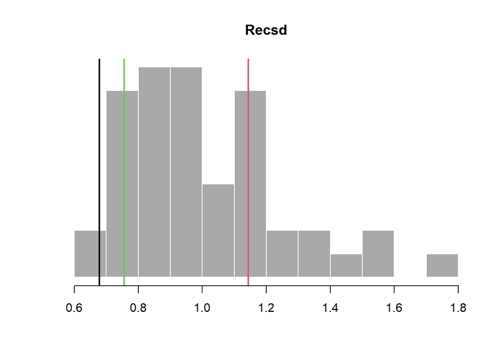

#### Time-Series

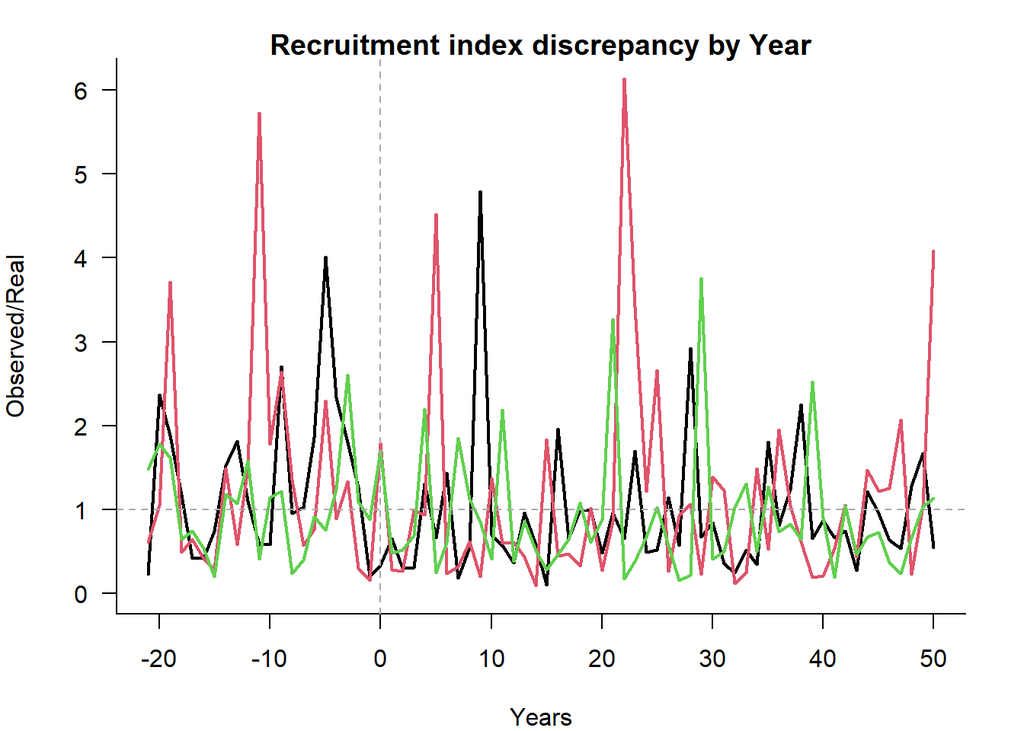

### Composition Observations

#### Sampled Parameters

Histograms of 48 simulations of catch-at-age effective sample size (`CAA_ESS`) and sample size (`CAA_nsamp`) and catch-at-length effective (`CAL_ESS`) and actual sample size (`CAL_nsamp`) with vertical colored lines indicating 3 randomly drawn values:

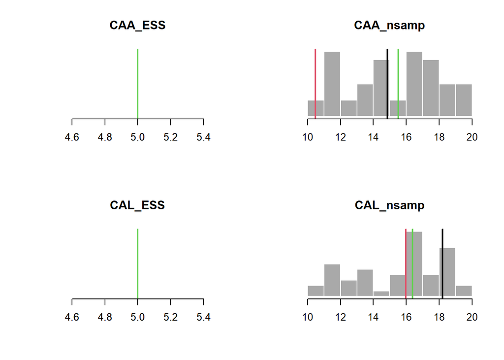

### Parameter Observations

#### Sampled Parameters

Histograms of 48 simulations of bias in observed natural mortality (`Mbias`), von Bertalanffy growth function parameters (`Linfbias`, `Kbias`, and `t0bias`), length-at-maturity (`lenMbias`), and bias in observed length at first capture (`LFCbias`) and first length at full capture (`LFSbias`) with vertical colored lines indicating 3 randomly drawn values:

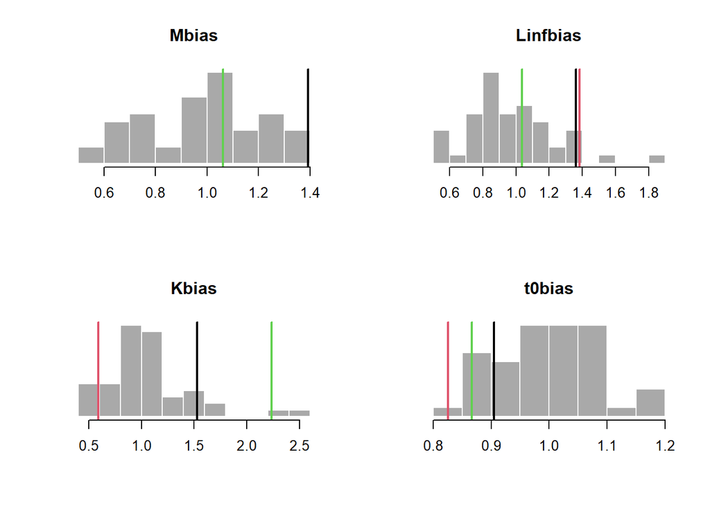

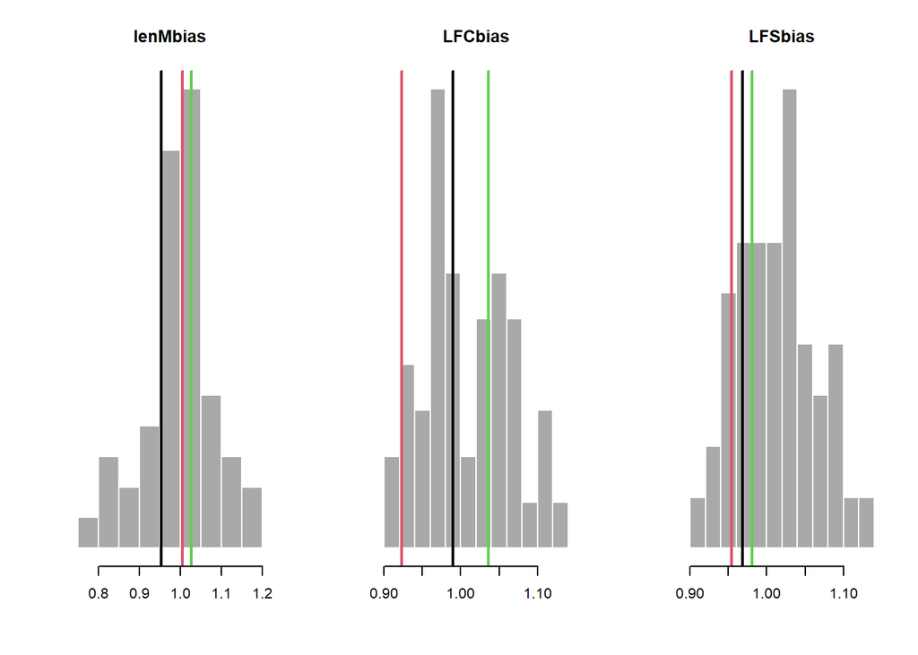

### Reference Point Observations

#### Sampled Parameters

Histograms of 48 simulations of bias in observed FMSY/M (`FMSY_Mbias`), BMSY/B0 (`BMSY_B0bias`), reference index (`Irefbias`), reference abundance (`Brefbias`) and reference catch (`Crefbias`), with vertical colored lines indicating 3 randomly drawn values:

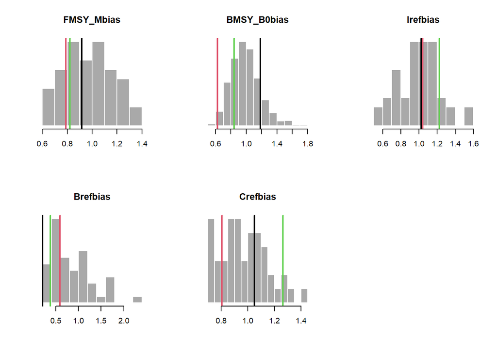

# Imp Parameters

We have assumed that TAC and TAE regulations are generally well implemented, and are usually with 10% of the regulated limit. Size regulations are assumed to be well implemented.These assumptions can be evaluated in a series of robustness tests.

### Output Control Implementation Error: TACFrac, TACSD

**TACFrac**: Mean fraction of TAC taken. Uniform distribution lower and upper bounds. Positive real number.

Specified Value(s): 0.9, 1.1

We assume that catches are usually between 90% and 110% of TAC.

**TACSD**: Log-normal coefficient of variation in the fraction of Total Allowable Catch (TAC) taken. Uniform distribution lower and upper bounds. Non-negative real numbers.

Specified Value(s): 0.05, 0.1

We assume a small amount of variability in implementation of TAC.

### Effort Control Implementation Error: TAEFrac, TAESD

**TAEFrac**: Mean fraction of TAE taken. Uniform distribution lower and upper bounds. Positive real number.

Specified Value(s): 0.9, 1.1

We assume that effort are usually between 90% and 110% of TAE.

**TAESD**: Log-normal coefficient of variation in the fraction of Total Allowable Effort (TAE) taken. Uniform distribution lower and upper bounds. Non-negative real numbers.

Specified Value(s): 0.05, 0.1

We assume a small amount of variability in implementation of TAE.

### Size Limit Control Implementation Error: SizeLimFrac, SizeLimSD

**SizeLimFrac**: The real minimum size that is retained expressed as a fraction of the size of retention. Uniform distribution lower and upper bounds. Positive real number.

Specified Value(s): 0.95, 1.05

We assume that size regulations are typically well enforced.

**SizeLimSD**: Log-normal coefficient of variation controlling mismatch between a minimum size limit and the real minimum size retained. Uniform distribution lower and upper bounds. Non-negative real numbers.

Specified Value(s): 0.05, 0.1

We assume a small amount of variability in implementation of size regulations.

## Implementation Parameters

### TAC Implementation

#### Sampled Parameters

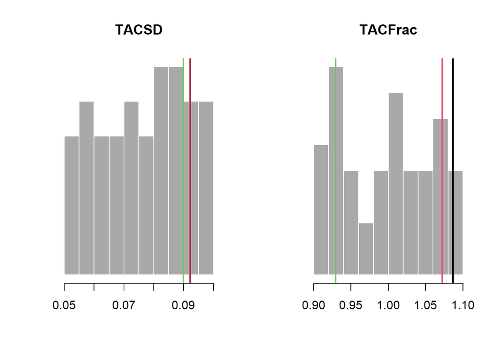

#### Time-Series

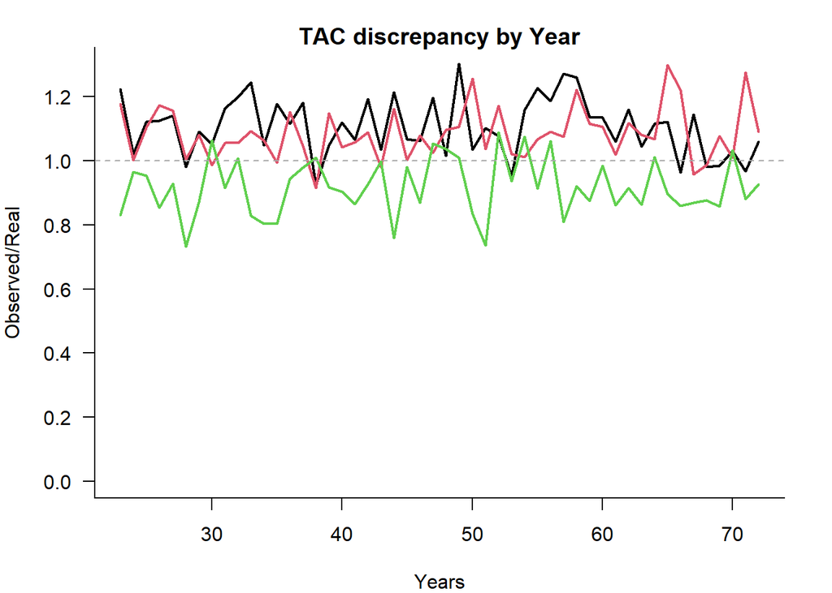

### TAE Implementation

#### Sampled Parameters

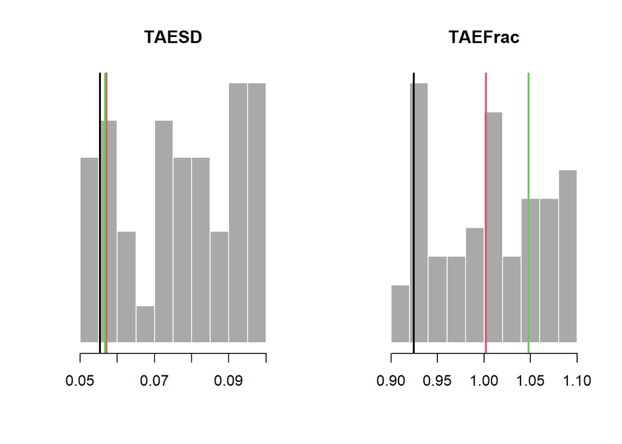

#### Time-Series

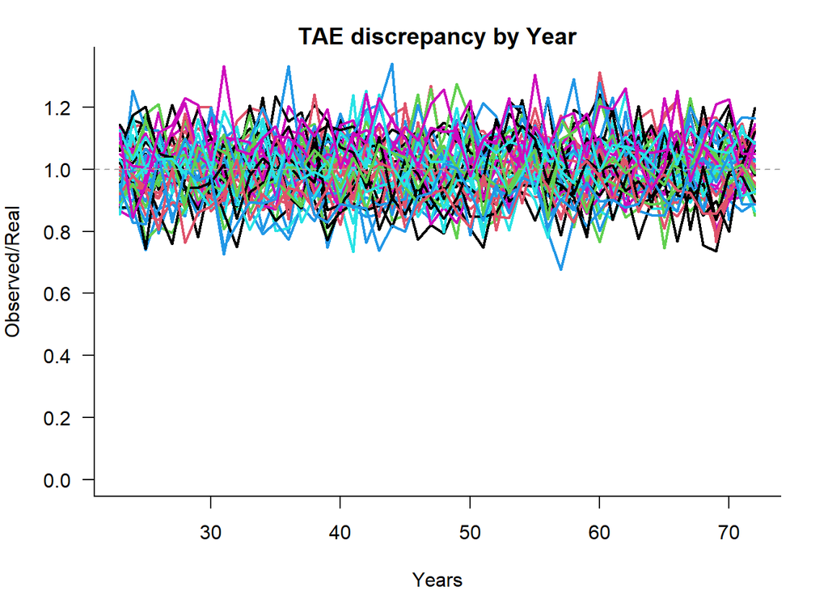

### Size Limit Implementation

#### Sampled Parameters

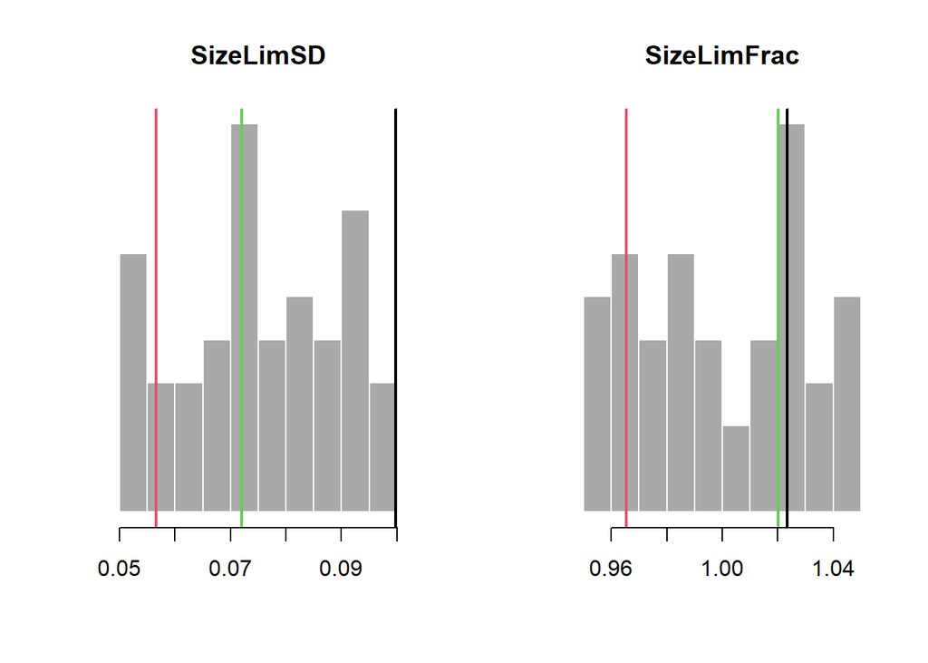

#### Time-Series

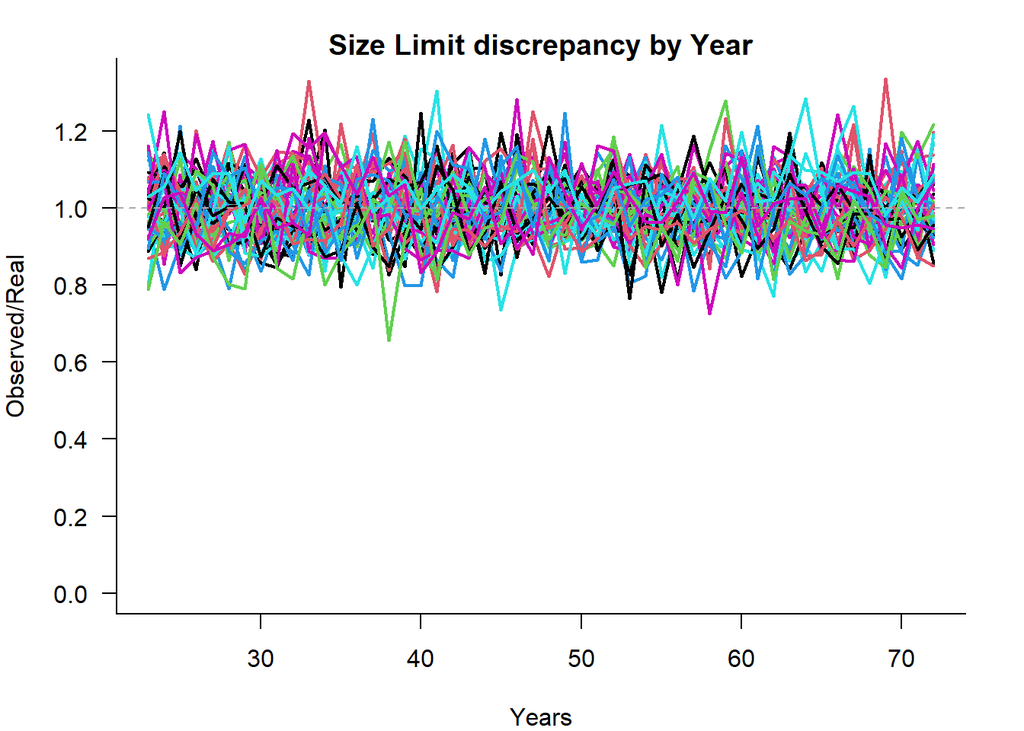

# Historical Simulation Plots

## Historical Time-Series

### Spawning Biomass

#### Depletion

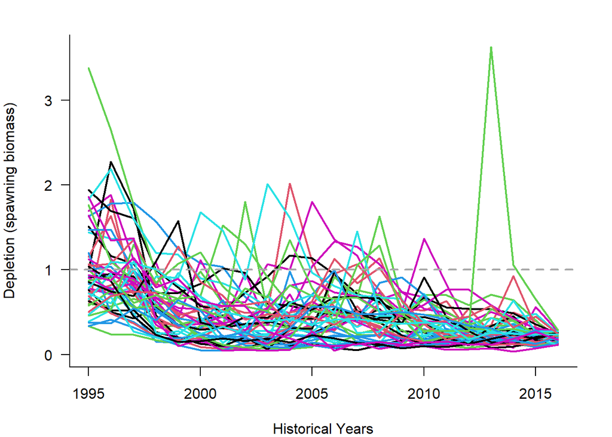

#### Absolute

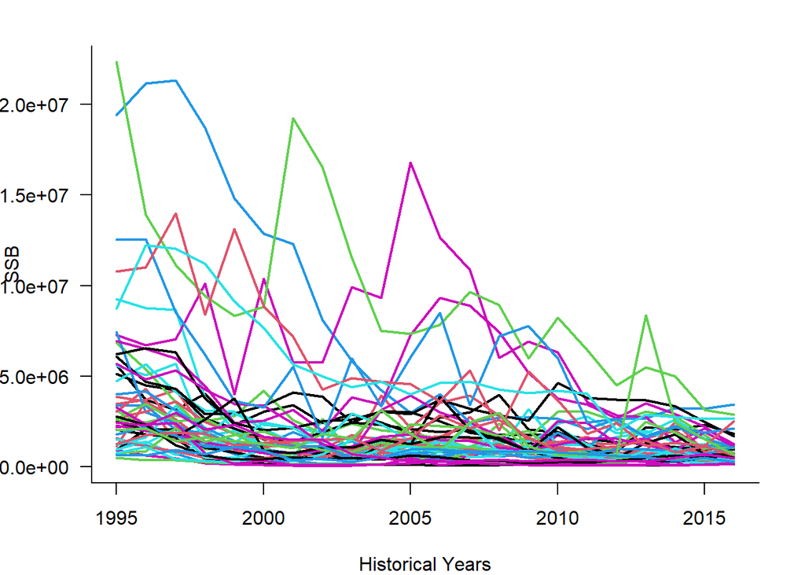

### Vulnerable Biomass

#### Depletion

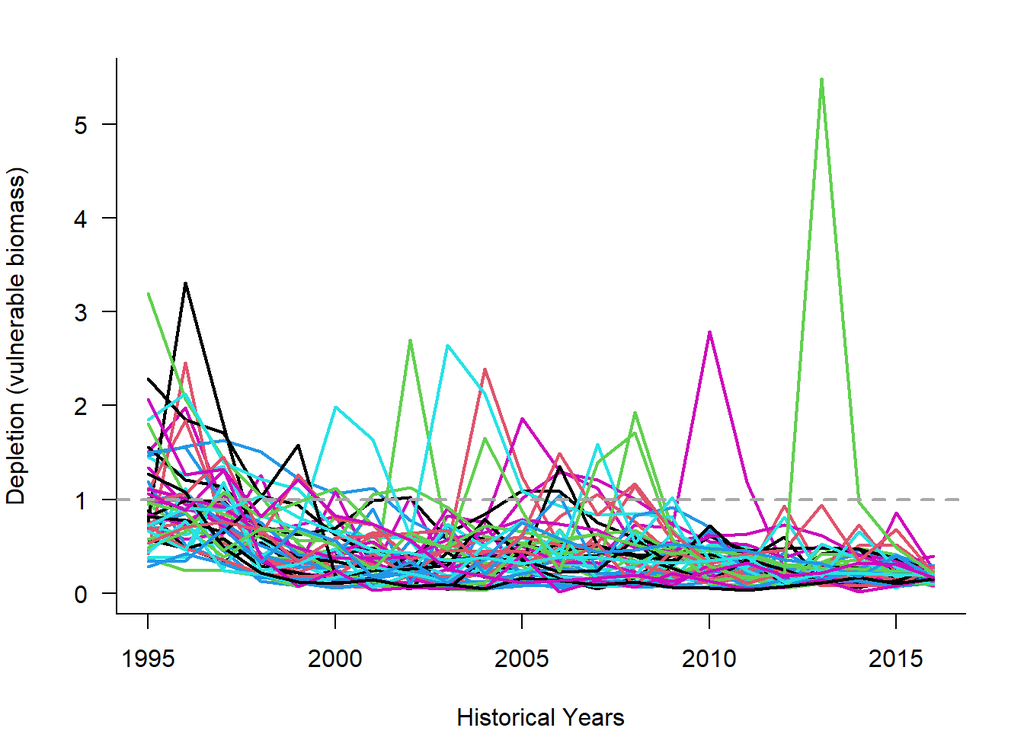

#### Absolute

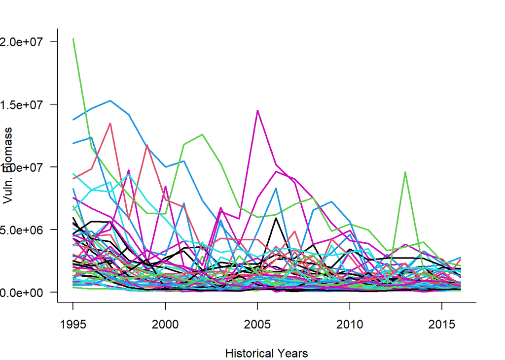

### Total Biomass

#### Depletion

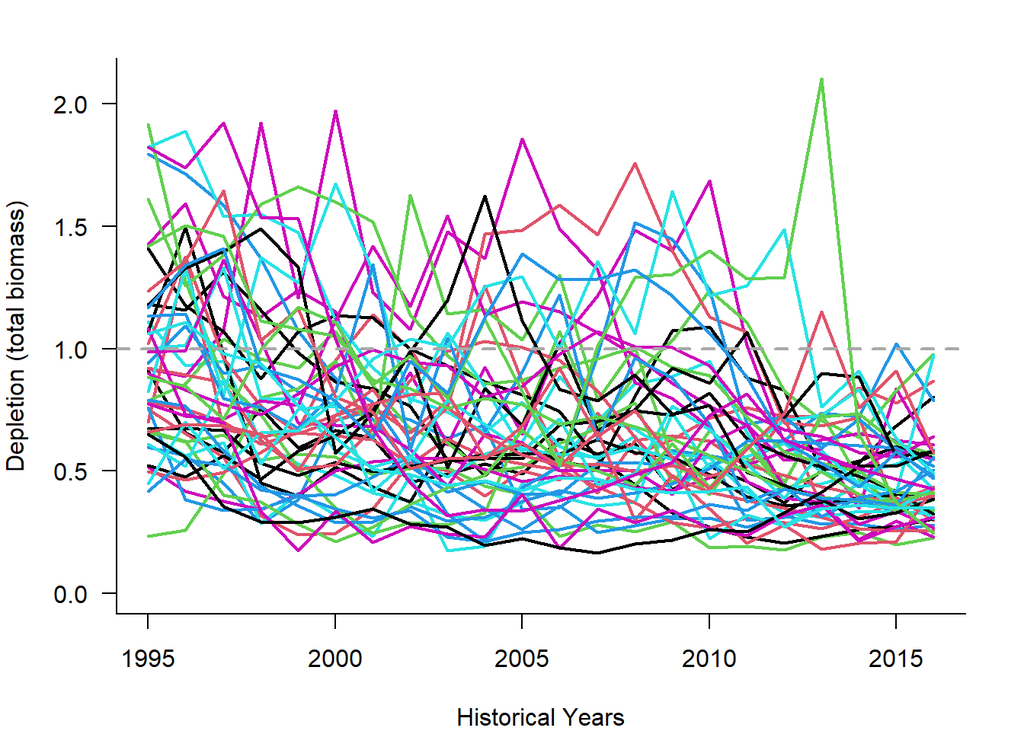

#### Absolute

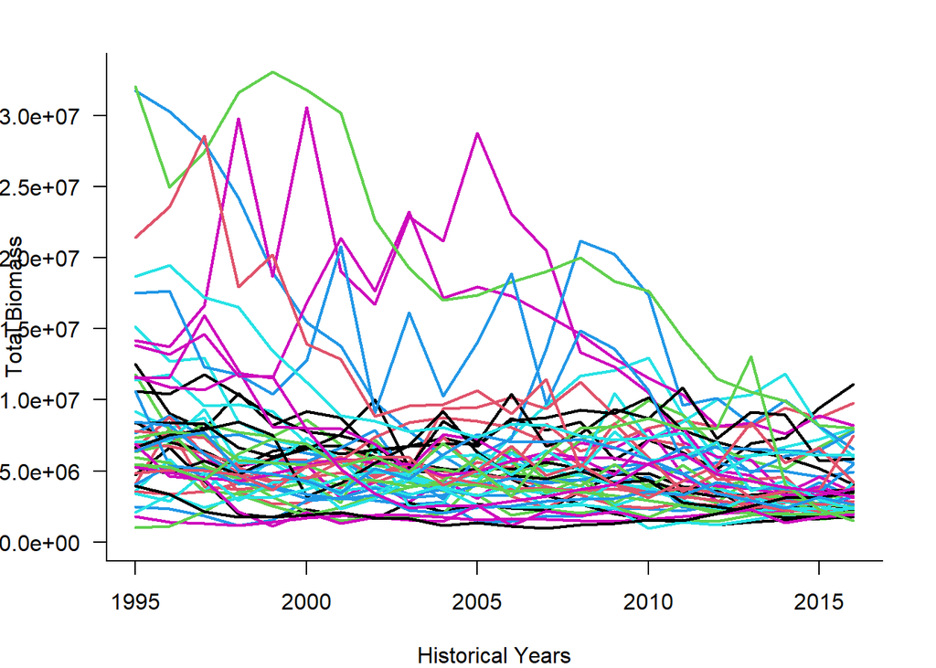

### Recruitment

#### Relative

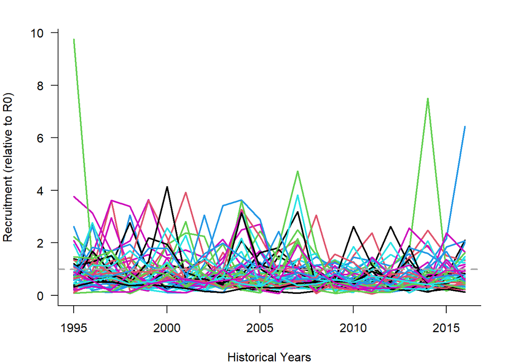

#### Absolute

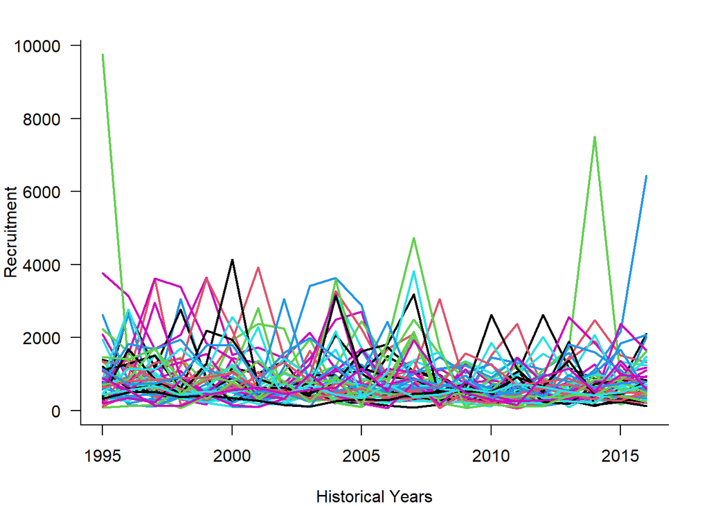

### Catch

#### Relative

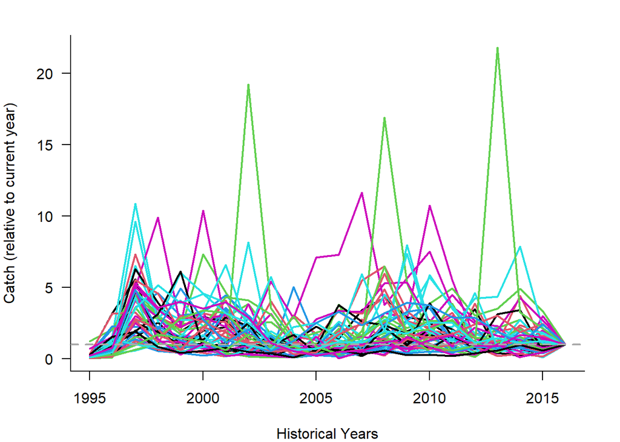

#### Absolute

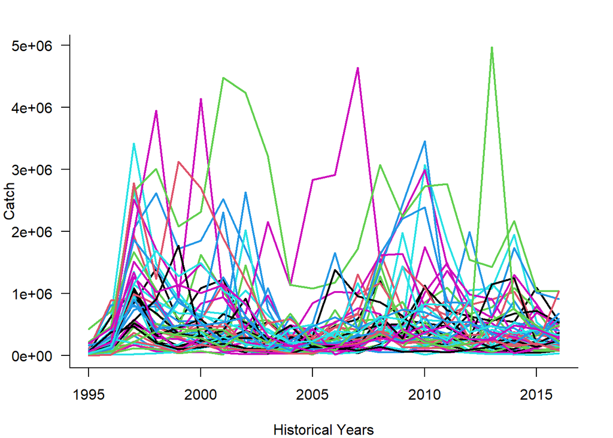

### Historical Fishing Mortality

#### Historical Time-Series

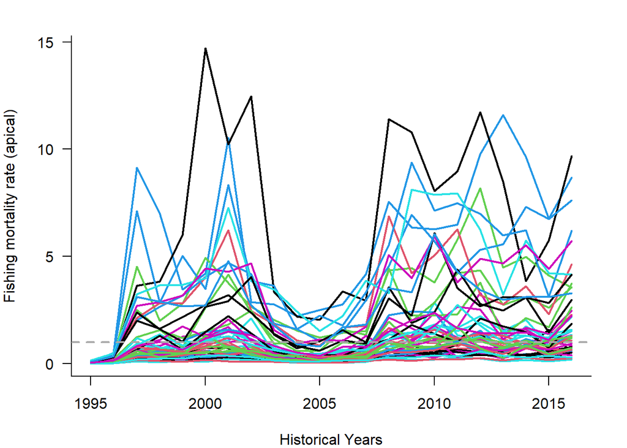

# References

Anon., 2013. Jonah crab (*Cancer borealis*) Current status and information sources. Gulf of Maine Research Institute and the University of Maine.

Cobb, J.S., Booth, J.D. and Clancy, M. (1997) Recruitment strategies in lobsters and crabs: a comparison. Marine and Freshwater Research 48, 797.

Hudon, C. and Lamarche, G. (1989) Niche segregation between American lobster *Homarus americanus* and rock crab *Cancer irroratus*. Marine Ecology Progress Series 52, 155–168.

Moriyasu, M., Benhalima, K, Duggan, D., Lawton, P., and Robichaud, D. 2002. Reproductive biology of male Jonah crab, Cancer borealis Stimpson, 1859 (Decapoda: Cancridae) on the Scotian Shelf, Northwestern Atlantic. Crustaceana 75: 891-913.

Pezzack, D.S., Frail, C.M., Reeves, A., and Tremblay, M.J, 2011. Assessment of the LFA 41 Offshore Jonah Crab (*Cancer borealis*) (NAFO 4X and 5Zc). DFO Can. Sc.i. Advis. Sec. Res. Doc. 2010/113:viii + 52p.

Robichaud, D.A., and Frail, C. 2006. Development of Jonah crab, *Cancer borealis*, and rock crab, *Cancer irroratus*, fisheries in the Bay of Fundy (LFAs 35-38) and off southwest Nova Scotia (LFA 34): from exploratory to commercial status (1995-2004). Can. Manuscr. Rep. Fish. Aquat. Sci. 2775: iii + 48 pp.

Sheeny, M.R.J. and Prior, A.E. (2008) Progress on an old question for stock assessment of the edible crab Cancer pagurus. Marine Ecology Progress Series 353, 191–202.

Shields, J.D. (1991) The reproductive ecology and fecundity of Cancer crabs. In: Crustacean egg production. (ed A.A. Balkema). Boston, Massachusetts, USA, pp 193–213.